# EDA 與建模報告：regression_house_price.csv

任務：迴歸（連續數值預測）｜目標：`price_wan`｜產生：2026-10-21 10:51｜遺失值：有，插補選用 中位數｜最佳模型：Gradient Boosting

**2,500**列數

**10**特徵數（數值 10 / 類別 0）

**4**有遺失的欄位數

**Gradient Boosting**最佳模型（依 CV）

**0.894**最佳模型測試 R²

## 1. 資料與變數介紹

- **資料說明**：模擬的都會區房屋成交資料：2,500 筆物件，依面積、格局、屋齡、樓層、區位與管理費等 10 個數值變數，預測成交總價（萬元）。其中 4 個變數有遺失值。
- **分析目的（要預測什麼）**：預測 `price_wan`——成交總價（預測目標），萬元；平均 1,217.1、範圍 117–4,952。這是一個迴歸問題（判斷依據見第 2 節）。
- **用了哪些變數**：10 個特徵（數值 10、類別 0）——`area_sqm`（室內面積，平方公尺）；`bedrooms`（房間數，間）；`bathrooms`（衛浴數，間）；`house_age`（屋齡（老公寓常沒有資料，MAR 遺失），年）；`floor`（所在樓層（隨機漏填，MCAR 遺失），樓）；`total_floors`（建物總樓層（≤5 多為無電梯老公寓），層）；`dist_center_km`（距市中心距離，公里）；`dist_mrt_km`（距最近捷運站距離（郊區常未標示，MAR 遺失），公里）；`parking_spaces`（車位數，個）；`mgmt_fee`（每月管理費（越高越不願意寫，MNAR 遺失），元/月）。
- 資料共 **2,500 筆、12 個欄位**：目標 1 個（`price_wan`）、特徵 10 個（數值 10、類別 0）、ID／排除 1 個。
- ID 類欄位 listing_id 只用來識別資料列，沒有預測意義，建模前排除（留著還可能造成洩漏）。
- 完全重複的列 0 筆；常數欄位 無。

### 變數與欄位介紹

| 欄位 | 說明 | 單位 | 角色 | 變數型態 | dtype | 遺失數 |
| --- | --- | --- | --- | --- | --- | --- |
| listing_id | 物件編號（識別碼，建模前會排除） | — | ID（排除） | 識別碼 | str | 0 |
| area_sqm | 室內面積 | 平方公尺 | 特徵 | 數值 | float64 | 0 |
| bedrooms | 房間數 | 間 | 特徵 | 數值 | int64 | 0 |
| bathrooms | 衛浴數 | 間 | 特徵 | 數值 | int64 | 0 |
| house_age | 屋齡（老公寓常沒有資料，MAR 遺失） | 年 | 特徵 | 數值 | float64 | 314 |
| floor | 所在樓層（隨機漏填，MCAR 遺失） | 樓 | 特徵 | 數值 | float64 | 118 |
| total_floors | 建物總樓層（≤5 多為無電梯老公寓） | 層 | 特徵 | 數值 | int64 | 0 |
| dist_center_km | 距市中心距離 | 公里 | 特徵 | 數值 | float64 | 0 |
| dist_mrt_km | 距最近捷運站距離（郊區常未標示，MAR 遺失） | 公里 | 特徵 | 數值 | float64 | 143 |
| parking_spaces | 車位數 | 個 | 特徵 | 數值 | int64 | 0 |
| mgmt_fee | 每月管理費（越高越不願意寫，MNAR 遺失） | 元/月 | 特徵 | 數值 | float64 | 396 |
| price_wan | 成交總價（預測目標） | 萬元 | 目標 | 數值（連續） | float64 | 0 |

## 2. 判斷任務類型（分類 or 迴歸）

- **判斷結果：迴歸（連續數值預測）**。理由：目標是數值且有 1,394 種不同值（佔 55.8%），雖為整數但取值很多，大小與差距都有意義。
- 迴歸 = 預測「連續數值是多少」；評估用 RMSE、MAE、R²、MAPE；切分用一般隨機 KFold。
- 判斷規則：文字／布林 → 分類；只有 2 種值 → 二元分類；整數且 ≤10 種值 → 多類別分類（需確認是否為計數/評分）；其餘數值 → 迴歸。任務類型決定了之後的模型（Classifier vs Regressor）、評估指標與切分方式，所以是第一步。

### 任務類型判斷

| 檢查項目 | 結果 |
| --- | --- |
| 目標欄位 | price_wan |
| dtype | float64 |
| 是否為數值 | 是 |
| 是否全為整數 | 是 |
| 不同值個數 | 1,394 |
| 不同值佔比 | 55.76% |
| 範例值 | 1332.0, 932.0, 2949.0, 934.0, 514.0, 820.0 |
| 判斷 | 迴歸：連續數值預測 |

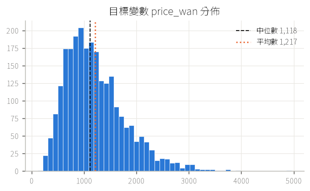

目標變數分佈：分類看各類別比例（是否不平衡）；迴歸看分佈形狀與偏態。

## 3. 敘述性統計

- 目標 price_wan 平均 1,217.1、中位數 1,117.5、偏態 1.09。右偏明顯：報告時中位數比平均數更有代表性；若在意相對誤差，可考慮對 log(y) 建模（sklearn 的 TransformedTargetRegressor）。
- 偏態 |skew|>1 的欄位：floor（1.25）、dist_center_km（1.46）、dist_mrt_km（3.29）。樹模型不受單調轉換影響，不必為了模型做 log；但線性模型或距離型插補（KNN）會受影響。
- 單變量與目標關係最強的特徵：area_sqm（Spearman ρ=0.66）、mgmt_fee（Spearman ρ=0.56）、bedrooms（Spearman ρ=0.51）、house_age（Spearman ρ=-0.44）。這只是單變量篩選，交互作用與非線性要靠後面的模型。

### 數值敘述統計

| 欄位 | 個數 | 遺失% | 平均數 | 標準差 | 最小值 | Q1 | 中位數 | Q3 | 最大值 | IQR | 變異係數CV | 偏態 | 峰態(超額) | 離群值數(1.5IQR) |
| --- | --- | --- | --- | --- | --- | --- | --- | --- | --- | --- | --- | --- | --- | --- |
| area_sqm | 2,500 | 0 | 90.19 | 31.36 | 23.2 | 67.6 | 86.35 | 107.4 | 289.7 | 39.8 | 0.348 | 0.935 | 1.593 | 53 |
| bedrooms | 2,500 | 0 | 3.021 | 1.227 | 1 | 2 | 3 | 4 | 6 | 2 | 0.406 | 0.355 | -0.311 | 0 |
| bathrooms | 2,500 | 0 | 2.129 | 0.872 | 1 | 1 | 2 | 3 | 4 | 2 | 0.409 | 0.339 | -0.63 | 0 |
| house_age | 2,186 | 12.56 | 21.57 | 14.33 | 0.3 | 9.5 | 17.7 | 33.2 | 60 | 23.7 | 0.664 | 0.621 | -0.68 | 0 |
| floor | 2,382 | 4.72 | 6.869 | 6.299 | 1 | 2 | 4 | 10 | 29 | 8 | 0.917 | 1.25 | 0.722 | 66 |
| total_floors | 2,500 | 0 | 12.74 | 9.146 | 2 | 4 | 11 | 21 | 30 | 17 | 0.718 | 0.434 | -1.252 | 0 |
| dist_center_km | 2,500 | 0 | 7.133 | 4.882 | 0.3 | 3.61 | 6.14 | 9.358 | 35 | 5.748 | 0.684 | 1.455 | 3.142 | 84 |
| dist_mrt_km | 2,357 | 5.72 | 0.649 | 0.758 | 0 | 0.16 | 0.41 | 0.85 | 9.54 | 0.69 | 1.168 | 3.287 | 19.65 | 145 |
| parking_spaces | 2,500 | 0 | 0.544 | 0.621 | 0 | 0 | 0 | 1 | 2 | 1 | 1.143 | 0.696 | -0.493 | 0 |
| mgmt_fee | 2,104 | 15.84 | 1,780 | 1,489 | 0 | 370 | 1,785 | 2,830 | 9,200 | 2,460 | 0.836 | 0.615 | -0.259 | 4 |
| price_wan | 2,500 | 0 | 1,217 | 577 | 117 | 797 | 1,118 | 1,523 | 4,952 | 726.2 | 0.474 | 1.086 | 1.798 | 63 |

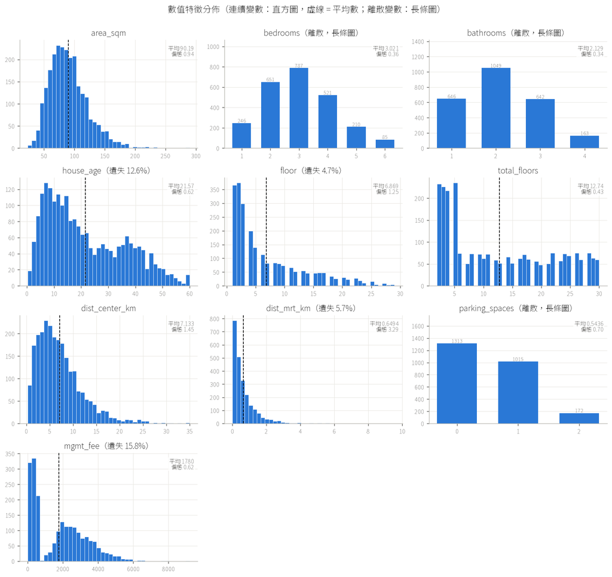

連續變數用直方圖（虛線為平均數），取值少的離散變數（如房間數、車位數）用長條圖；右上角為平均數與偏態。

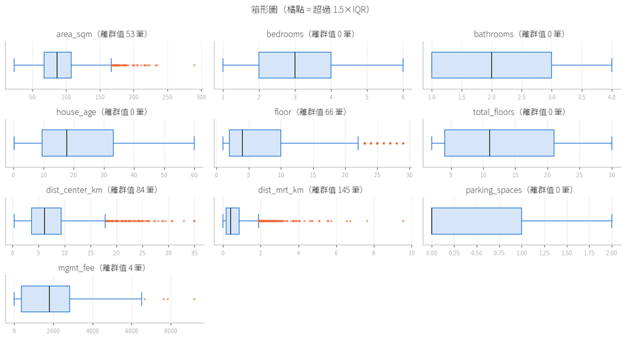

箱形圖：橘點為 1.5×IQR 外的離群值；樹模型對離群值穩健，但明顯的輸入錯誤仍應修正。

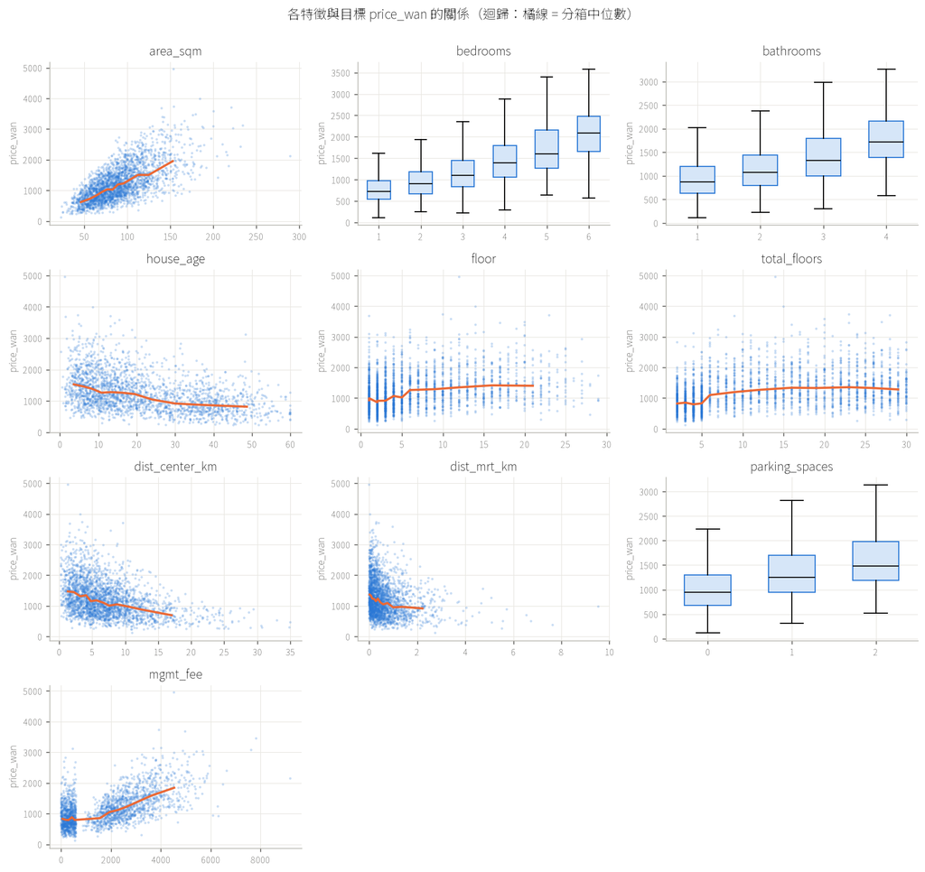

雙變量分析：分類看各類別的分佈差異或各水準的目標比率；迴歸看趨勢與非線性。

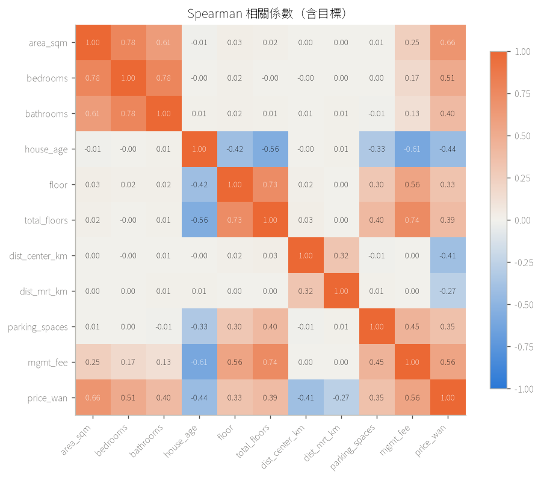

Spearman 相關（對偏態與單調非線性較穩健）：找共線性與和目標相關的特徵。

## 4. 遺失值檢查與診斷

- **有遺失值**：4 個特徵欄位有遺失，共 971 格（佔 3.88%）。接下來進行遺失機制診斷（本節），並在切分資料後比較插補方法（第 6 節）。

### 遺失值檢查

| 項目 | 結果 |
| --- | --- |
| 特徵欄位數 | 10 |
| 資料筆數 | 2500 |
| 總格數 | 25,000 |
| 遺失格數 | 971（3.88%） |
| 有遺失的欄位數 | 4：house_age, floor, dist_mrt_km, mgmt_fee |
| 完整列比例 | 64.9% |
| 判斷 | 有遺失 → 進行遺失機制診斷與插補比較 |

- **行（欄位）遺失比例**＝某欄位遺失的筆數 ÷ 總筆數：mgmt_fee 15.8%、house_age 12.6%、dist_mrt_km 5.7%、floor 4.7%；其餘 6 個欄位為 0%。
- **列（資料筆）遺失比例**＝某筆資料遺失的欄位數 ÷ 特徵數（10）：完整（0 個遺失）的資料 1,622 筆（64.9%）；至少遺失 1 個欄位 878 筆（35.1%）；單筆最多遺失 3 個欄位（該列遺失比例 30%）。若直接刪除含遺失的列，會丟掉 35.1% 的資料。
- Little MCAR 整體檢定：χ²=695.4、df=98、p=9e-91 → **拒絕 MCAR**：至少有部分欄位的遺失和其他變數有關，直接刪除遺失列會造成樣本偏誤。
- 提醒：MAR 可以從資料看到跡象（遺失率隨其他欄位變化）；MNAR（遺失取決於值本身）無法從觀測資料證明，只能靠領域知識判斷。標成「MAR（或 MNAR）」的欄位，兩種都有可能。

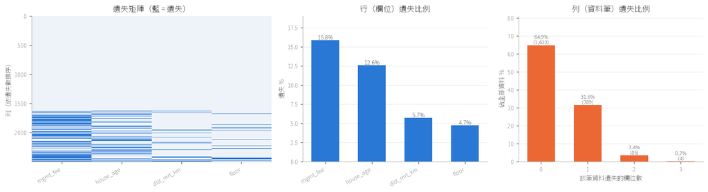

左：遺失矩陣（欄位依遺失比例由高到低排列，與中圖同順序）；中：行（欄位）遺失比例；右：列（資料筆）遺失比例——每筆資料遺失幾個欄位、各佔多少。

### 行（欄位）遺失比例

| 欄位 | 遺失數 | 行遺失比例% |
| --- | --- | --- |
| mgmt_fee | 396 | 15.84 |
| house_age | 314 | 12.56 |
| dist_mrt_km | 143 | 5.72 |
| floor | 118 | 4.72 |
| area_sqm | 0 | 0 |
| bedrooms | 0 | 0 |
| bathrooms | 0 | 0 |
| total_floors | 0 | 0 |
| dist_center_km | 0 | 0 |
| parking_spaces | 0 | 0 |

### 列（資料筆）遺失比例

| 該列遺失的欄位數 | 資料筆數 | 佔全部資料% | 該列遺失比例% |
| --- | --- | --- | --- |
| 0 | 1,622 | 64.88 | 0 |
| 1 | 789 | 31.56 | 10 |
| 2 | 85 | 3.4 | 20 |
| 3 | 4 | 0.16 | 30 |

### 遺失機制診斷

[output not shown]

## 5. 資料切分

- **為什麼要切分**：模型在「看過的資料」上的分數一定偏樂觀（尤其是會記住資料的深樹）。必須留一份完全沒碰過的資料，才能估計上線後的真實表現。
- **本次做法**：先切出 25% 測試集（625 筆，鎖起來直到最後），剩下 1,875 筆訓練集再做 5 折交叉驗證（KFold）：每次用 4 折訓練、1 折驗證，輪流 5 次取平均。插補法與模型都用 CV 分數挑選，測試集只在最後報告一次。
- **迴歸用一般 KFold**：目標是連續值，沒有類別比例可維持；若目標很偏或樣本少，可以先把目標分箱再 stratify。
- 訓練集 / 測試集的目標平均為 1,214.8 / 1,224.2，中位數 1,114.0 / 1,133.0；KS 檢定 p=0.56（>0.05 代表兩者分佈沒有明顯差異）。
- **避免洩漏**：插補、編碼、特徵選擇都放進 Pipeline，在每一折只用該折的訓練資料 fit；**不要**在切分前對全部資料算平均數補值或標準化。
- **其他切分情境**：有時間順序 → TimeSeriesSplit（只能用過去預測未來）；同一客戶/病人有多筆 → GroupKFold（同一群不能同時出現在訓練與驗證）；Boosting 的 early stopping → 再從訓練集切出一小份驗證集；資料很少 → 用重複 CV（RepeatedKFold）讓估計更穩。

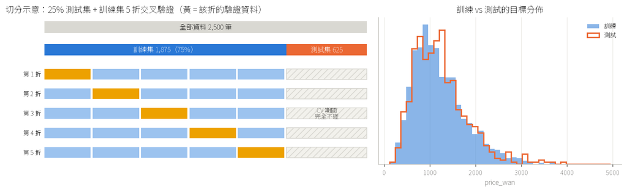

左：切分流程——測試集先鎖起來，訓練集內輪流用其中 1 折當驗證；右：檢查切分後目標分佈是否一致。

### 資料切分

| 集合 | 筆數 | 佔全部% | 平均數 | 中位數 | 標準差 | 最小值 | 最大值 |
| --- | --- | --- | --- | --- | --- | --- | --- |
| 全部資料 | 2,500 | 100 | 1,217 | 1,118 | 577 | 117 | 4,952 |
| 訓練集 | 1,875 | 75 | 1,215 | 1,114 | 574 | 227 | 4,952 |
| 測試集 | 625 | 25 | 1,224 | 1,133 | 586.2 | 117 | 3,984 |

### 交叉驗證各折

| 折 | 訓練筆數 | 驗證筆數 | 訓練 目標平均 | 驗證 目標平均 |
| --- | --- | --- | --- | --- |
| 1 | 1,500 | 375 | 1,213 | 1,222 |
| 2 | 1,500 | 375 | 1,205 | 1,255 |
| 3 | 1,500 | 375 | 1,228 | 1,163 |
| 4 | 1,500 | 375 | 1,219 | 1,196 |
| 5 | 1,500 | 375 | 1,209 | 1,238 |

## 6. 遺失值處理：插補方法比較

- 第 4 節的診斷建議部分欄位保留遺失指標；實測「中位數+遺失指標」CV RMSE 199.3，與選用的 中位數 200.0 差距在雜訊內，代表其他特徵已能補足這個訊號，所以選較簡單的做法。
- 下游模型（Gradient Boosting，5-fold CV RMSE）比較：整列刪除(listwise) 227.1、中位數 200.0、平均數 199.7、中位數+遺失指標 199.3、KNN(k=5) 199.7、MICE(貝氏迴歸) 201.4、MICE(ExtraTrees) 197.6。
- 選用 **中位數**：分數最佳為 MICE(ExtraTrees)，在 1 個標準誤（≈3.9）內挑最簡單的方法，避免為了雜訊等級的差距增加複雜度。
- 遮罩還原（模擬 MCAR）平均 NRMSE 最低：MICE(ExtraTrees)（0.675），平均數插補 0.958。數值還原準不等於預測好——樹模型更在乎「遺失本身」這個訊號。

### 插補比較_下游CV

| 插補法 | CV RMSE 平均 | CV RMSE 標準差 | 耗時(秒) | 備註 |
| --- | --- | --- | --- | --- |
| 整列刪除(listwise) | 227.1 | 10.81 | 1.5 | 訓練只用完整列（約 66%）；驗證折含遺失列時仍得插補才能預測 |
| 中位數 | 200 | 8.29 | 2 |  |
| 平均數 | 199.7 | 9.907 | 2 |  |
| 中位數+遺失指標 | 199.3 | 8.877 | 2.1 |  |
| KNN(k=5) | 199.7 | 10.66 | 2.3 |  |
| MICE(貝氏迴歸) | 201.4 | 8.642 | 2.5 |  |
| MICE(ExtraTrees) | 197.6 | 8.116 | 14.4 |  |

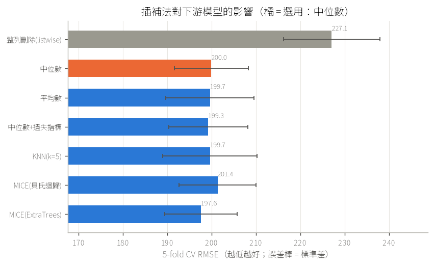

### 插補比較_遮罩還原NRMSE

| 插補法 | house_age | floor | dist_mrt_km | mgmt_fee | area_sqm | bedrooms | bathrooms | total_floors | dist_center_km | parking_spaces | 平均 |
| --- | --- | --- | --- | --- | --- | --- | --- | --- | --- | --- | --- |
| 中位數 | 0.9434 | 0.9762 | 0.8384 | 0.9731 | 1.036 | 0.9729 | 1.058 | 0.9787 | 0.9858 | 1.333 | 1.01 |
| 平均數 | 0.9322 | 0.904 | 0.8119 | 0.9728 | 1.032 | 0.9726 | 1.034 | 0.9617 | 0.9617 | 1.003 | 0.9585 |
| 中位數+遺失指標 | 0.9434 | 0.9762 | 0.8384 | 0.9731 | 1.036 | 0.9729 | 1.058 | 0.9787 | 0.9858 | 1.333 | 1.01 |
| KNN(k=5) | 0.7487 | 0.806 | 0.8144 | 0.5906 | 0.7478 | 0.6476 | 0.812 | 0.6753 | 1.014 | 0.9078 | 0.7765 |
| MICE(貝氏迴歸) | 0.7458 | 0.7013 | 0.8067 | 0.5948 | 0.6347 | 0.4886 | 0.6166 | 0.5797 | 0.9 | 0.8677 | 0.6936 |
| MICE(ExtraTrees) | 0.6259 | 0.7323 | 0.8298 | 0.37 | 0.6181 | 0.5416 | 0.6743 | 0.5637 | 0.9123 | 0.8851 | 0.6753 |

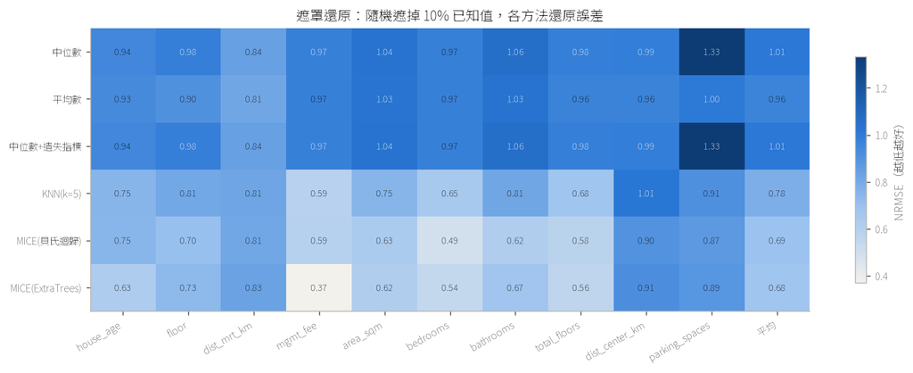

NRMSE = RMSE / 標準差；1.0 約等於用平均數猜。有相關欄位可借力的變數，KNN/MICE 會明顯較好。

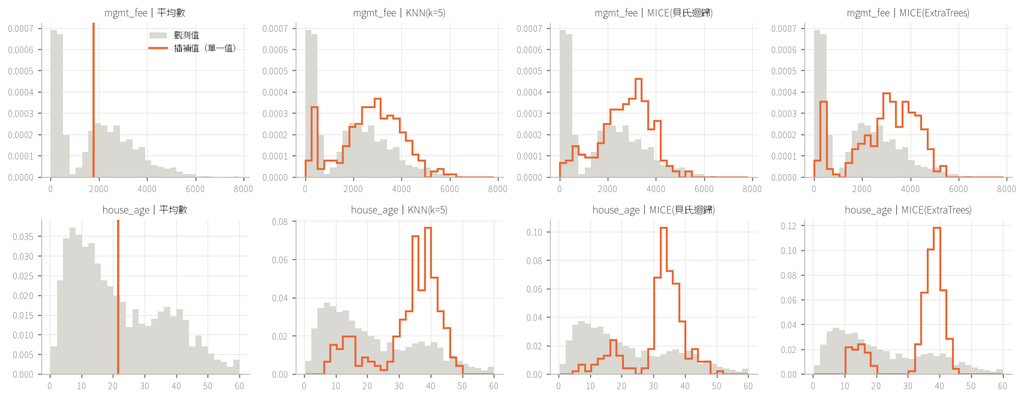

插補值分佈 vs 觀測值：平均數插補把所有遺失擠在同一點，會壓縮變異、扭曲分佈。

### 插補比較_標準差比

| 插補法 | house_age | floor | dist_mrt_km | mgmt_fee |
| --- | --- | --- | --- | --- |
| 中位數 | 0.9411 | 0.9812 | 0.9735 | 0.9191 |
| 平均數 | 0.9369 | 0.9768 | 0.9705 | 0.9191 |
| 中位數+遺失指標 | 0.9411 | 0.9812 | 0.9735 | 0.9191 |
| KNN(k=5) | 1.004 | 0.9906 | 0.9936 | 1.008 |
| MICE(貝氏迴歸) | 0.9882 | 0.9876 | 0.9803 | 0.9881 |
| MICE(ExtraTrees) | 1.006 | 0.9904 | 0.9833 | 1.027 |

## 7. 模型訓練與比較（迴歸）

- 比較三個樹模型：**Decision Tree**（單棵樹，可解釋）、**Random Forest**（多棵深樹平均，降方差）、**Gradient Boosting**（多棵淺樹接力修正殘差，降偏差）。三者使用相同的前處理 Pipeline 與相同的 CV 折，比較才公平。
- **調參方式**：每個樹模型都用 **GridSearchCV** 在訓練集上做 5 折交叉驗證，窮舉「模型參數與調參」表中的參數組合，選 CV RMSE 最好的一組，再用整個訓練集重新訓練；最後只在測試集評估一次。註：調參後的 CV 分數因為是「挑過的最佳值」而略偏樂觀，所以最終以測試集確認。
- ⚠ 最佳參數落在搜尋範圍的邊界：Gradient Boosting 的 max_depth=3。代表更好的值可能在範圍外，實務上應擴大該參數的搜尋範圍再跑一次。
- 指標：RMSE（誤差的平方平均再開根號，對大誤差敏感，單位同目標）、MAE（平均絕對誤差，較穩健）、R²（解釋了多少變異，1=完美、0=等同猜平均）、MAPE（平均百分比誤差）。
- 依 CV 選出最佳模型 **Gradient Boosting**：CV RMSE 194.9±8.9，測試集 RMSE 190.7、MAE 141.1、R² 0.894、MAPE 12.0%（目標標準差 586.2；RMSE 越接近 0 越好）。
- 測試/訓練 RMSE 比 1.53：過擬合可接受。
- 置換重要度（測試集）前五名：area_sqm（429.9135）、dist_center_km（169.3389）、house_age（93.4242）、dist_mrt_km（41.1627）、parking_spaces（37.3375）。數值 = 打亂該欄後 RMSE 變差多少；接近 0 或為負的欄位對模型幾乎沒貢獻。重要度不是因果。

### 模型參數與調參

| 模型 | 調參方式 | 搜尋範圍 | 最佳參數 | 固定參數 | 前處理 |
| --- | --- | --- | --- | --- | --- |
| Decision Tree | GridSearchCV（5 折 CV，24 組 × 5 折 = 120 次訓練） | max_depth ∈ [4, 6, 8, 10, 12, None]；min_samples_leaf ∈ [1, 5, 10, 20] | max_depth=12、min_samples_leaf=10 | criterion=squared_error、random_state=42 | 數值直接輸入＋遺失值插補：中位數 |
| Random Forest | GridSearchCV（5 折 CV，9 組 × 5 折 = 45 次訓練） | max_features ∈ ['sqrt', 0.5, 1.0]；min_samples_leaf ∈ [1, 3, 5] | max_features=1.0、min_samples_leaf=1 | n_estimators=300、bootstrap=True、random_state=42 | 數值直接輸入＋遺失值插補：中位數 |
| Gradient Boosting | GridSearchCV（5 折 CV，12 組 × 5 折 = 60 次訓練） | n_estimators ∈ [200, 400]；learning_rate ∈ [0.05, 0.1]；max_depth ∈ [3, 4, 5] | learning_rate=0.05、max_depth=3、n_estimators=400 | subsample=0.8、random_state=42 | 數值直接輸入＋遺失值插補：中位數 |

### 參數說明

| 參數 | 中文 | 意義與影響 |
| --- | --- | --- |
| max_depth | 最大深度 | 樹最多切幾層；越深越能擬合細節，但越容易過擬合（None = 不限制） |
| min_samples_leaf | 葉節點最少樣本數 | 每片葉子至少要有幾筆資料；越大越平滑、越不容易過擬合 |
| max_features | 每次分裂考慮的特徵比例 | RF 每個節點只從隨機抽出的特徵中找切點；越小樹之間越不相關（sqrt = √特徵數） |
| n_estimators | 樹的數量 | 集成中的樹數；RF 越多越穩定，Boosting 太多會過擬合（需搭配學習率） |
| learning_rate | 學習率 η | Boosting 每棵樹的貢獻縮放；越小越穩但需要更多樹 |
| subsample | 列抽樣比例 | 每棵樹只用部分資料訓練（隨機梯度提升），可降低過擬合 |

### 模型比較

| 模型 | 插補 | CV RMSE | CV RMSE 標準差 | 訓練 RMSE | 測試 RMSE | 測試 MAE | 測試 R² | 測試 MAPE% |
| --- | --- | --- | --- | --- | --- | --- | --- | --- |
| Decision Tree | 中位數 | 276.4 | 7.214 | 190.8 | 274 | 205.6 | 0.7812 | 18.11 |
| Random Forest | 中位數 | 217.1 | 7.051 | 78.16 | 217.3 | 162.1 | 0.8624 | 14.44 |
| Gradient Boosting | 中位數 | 194.9 | 8.862 | 124.2 | 190.7 | 141.1 | 0.894 | 11.97 |

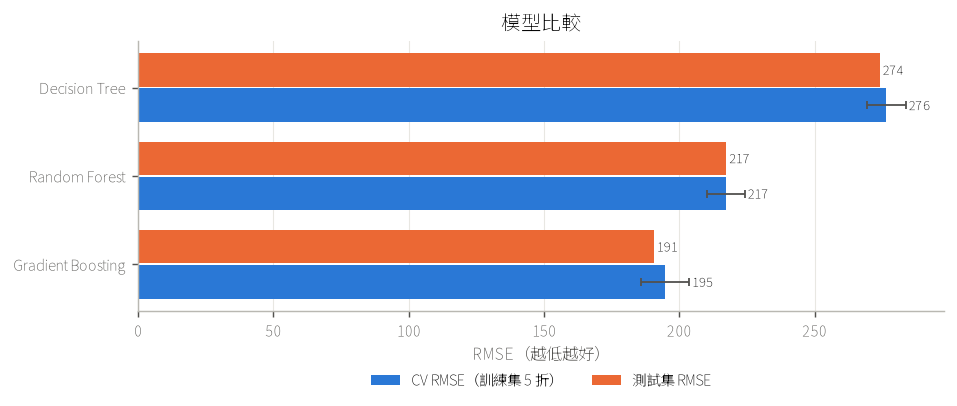

以 CV 選模型、測試集只做最終確認；誤差棒為 CV 標準差。

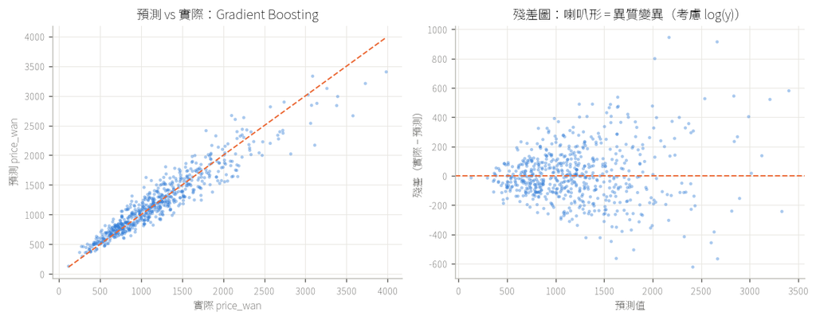

點越貼近對角線越準；殘差隨預測值擴大代表誤差和價格成比例，可考慮對 log(y) 建模或看 MAPE。

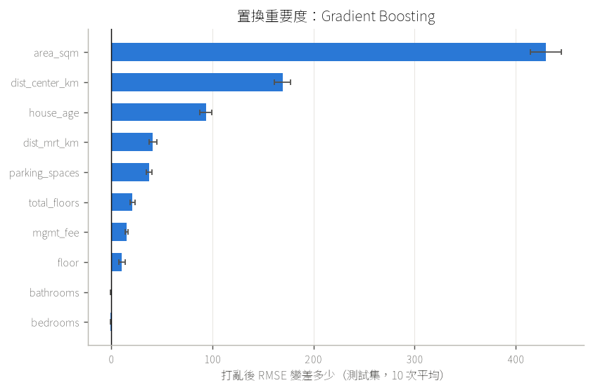

以原始欄位為單位計算（one-hot 與遺失指標一起算），比 impurity 重要度更不易被高基數 / 雜訊欄位騙。

所有表格另存於 descriptive_stats.xlsx；圖檔在 figures/。